# Requirements

- Change the file name to yourlastname_firstinitial_HW_Pandas_for_TextAnalytics
- import **smallsample_tweet_from_azuredatafactory.csv** and complete all the cells below. If necessary, you can create more cells.
- Change the filename to **yourlastname_firstinitial_HW_Pandas_for_TextAnalytics**
- Use **df.head()**, not df

# Rajiv Puli,"On my honor, as a student, I have neither given nor received unauthorized aid on this academic work."

```python
# Get the libraries you need.
import pandas as pd
import csv
import re
```

Import data and display five rows

```python
df = pd.read_csv('/Users/rajivpuli/Desktop/TacoBellvsMcDonalds.csv', encoding='UTF-8')
df.head()
```

|  | author_id | Tweet |
| --- | --- | --- |
| 0 | McDonalds | @115808 Itƒ??s getting all sorts of saucy over... |
| 1 | McDonalds | So whatƒ??ll it be this #Halloween: a trick or... |
| 2 | TacoBellTeam | @127797 DM us. Let's talk. https://t.co/FUsmRW... |
| 3 | TacoBellTeam | @127797 Thanks for the heads up. We're on it. ... |
| 4 | McDonalds | @115809 Our heartƒ??s beating faster over here... |

What are the number of rows in the dataset

```python
len(df)
```

```
5566
```

## Below, you need to transform / clean / analyze the tweets.

- You can use more than one cell to respond to each requirement.
- After data transformation/cleaning/analysis, make sure to update the data (df).
- Display the first five rows after each data transformation/cleaning/analysis.
- You may need to import additional libraries.

### Data transformation & exploratory data analysis

Lowercase words (you need to **update** your data --> the tweets need to be lowercased)

```python
df['Tweet'] = df['Tweet'].str.lower()
df.head(5)
```

|  | author_id | Tweet |
| --- | --- | --- |
| 0 | McDonalds | @115808 itƒ??s getting all sorts of saucy over... |
| 1 | McDonalds | so whatƒ??ll it be this #halloween: a trick or... |
| 2 | TacoBellTeam | @127797 dm us. let's talk. https://t.co/fusmrw... |
| 3 | TacoBellTeam | @127797 thanks for the heads up. we're on it. ... |
| 4 | McDonalds | @115809 our heartƒ??s beating faster over here... |

Show the number or percentage of "McDonalds Tweets" in the data and display the result below

```python
df.groupby('author_id').size()
```

```
author_id
McDonalds       3971
TacoBellTeam    1595
dtype: int64
```

### There are total 3971 number of McDonalds tweets in the dataset.

Show the number or percentage of "Taco Bell Tweets" in the data and display the result below

```python
df.groupby('author_id').size()
```

```
author_id
McDonalds       3971
TacoBellTeam    1595
dtype: int64
```

Find out the number of words in each tweet and create a column "wordcount"

```python
df['Tweet'].str.len()
```

```
0       106
1       112
2        50
3        50
4       121
       ...
5561     43
5562     72
5563     46
5564     49
5565     68
Name: Tweet, Length: 5566, dtype: int64
```

```python
df['wordcount'] = df['Tweet'].str.len()
df.head(5)
```

|  | author_id | Tweet | wordcount |
| --- | --- | --- | --- |
| 0 | McDonalds | @115808 itƒ??s getting all sorts of saucy over... | 106 |
| 1 | McDonalds | so whatƒ??ll it be this #halloween: a trick or... | 112 |
| 2 | TacoBellTeam | @127797 dm us. let's talk. https://t.co/fusmrw... | 50 |
| 3 | TacoBellTeam | @127797 thanks for the heads up. we're on it. ... | 50 |
| 4 | McDonalds | @115809 our heartƒ??s beating faster over here... | 121 |

Find the average word length and create a column "avgwordlen"

```python
df['Tweet'].str.len().sum() / len(df)
```

```
70.3898670499461
```

```python
df['avgwordlen'] = df['Tweet'].str.len().sum() / len(df)
df.head(5)
```

|  | author_id | Tweet | wordcount | avgwordlen |
| --- | --- | --- | --- | --- |
| 0 | McDonalds | @115808 itƒ??s getting all sorts of saucy over... | 106 | 70.389867 |
| 1 | McDonalds | so whatƒ??ll it be this #halloween: a trick or... | 112 | 70.389867 |
| 2 | TacoBellTeam | @127797 dm us. let's talk. https://t.co/fusmrw... | 50 | 70.389867 |
| 3 | TacoBellTeam | @127797 thanks for the heads up. we're on it. ... | 50 | 70.389867 |
| 4 | McDonalds | @115809 our heartƒ??s beating faster over here... | 121 | 70.389867 |

Find URLS and create a column "URL"

```python
df.Tweet.str.contains('http\S+|www.\S+', '').sum()
```

```
621
```

### There are total 621 URL's in different tweets.

```python
df['URL'] = df.Tweet.str.contains('http\S+|www.\S+', '')
df.head()
```

|  | author_id | Tweet | wordcount | avgwordlen | URL |
| --- | --- | --- | --- | --- | --- |
| 0 | McDonalds | @115808 itƒ??s getting all sorts of saucy over... | 106 | 70.389867 | True |
| 1 | McDonalds | so whatƒ??ll it be this #halloween: a trick or... | 112 | 70.389867 | True |
| 2 | TacoBellTeam | @127797 dm us. let's talk. https://t.co/fusmrw... | 50 | 70.389867 | True |
| 3 | TacoBellTeam | @127797 thanks for the heads up. we're on it. ... | 50 | 70.389867 | False |
| 4 | McDonalds | @115809 our heartƒ??s beating faster over here... | 121 | 70.389867 | True |

### New column URL is created.

Find the average number of URLs per tweet and display it below

```python
df.Tweet.str.contains('http\S+|www.\S+', '').sum() / len(df)
```

```
0.1115702479338843
```

### The average number of URL's in tweets is 0.11

### Text cleaning

Remove numbers in tweets and update the column

```python
df.Tweet.str.replace('\d+', '')
df.head()


#df.Tweet.str.replace('[^a-zA-Z0-9]+', ' ')
#df.head()
```

|  | author_id | Tweet | wordcount | avgwordlen | URL |
| --- | --- | --- | --- | --- | --- |
| 0 | McDonalds | @115808 itƒ??s getting all sorts of saucy over... | 106 | 70.389867 | True |
| 1 | McDonalds | so whatƒ??ll it be this #halloween: a trick or... | 112 | 70.389867 | True |
| 2 | TacoBellTeam | @127797 dm us. let's talk. https://t.co/fusmrw... | 50 | 70.389867 | True |
| 3 | TacoBellTeam | @127797 thanks for the heads up. we're on it. ... | 50 | 70.389867 | False |
| 4 | McDonalds | @115809 our heartƒ??s beating faster over here... | 121 | 70.389867 | True |

Remove urls and the update the column

```python
df.Tweet.str.replace('http\S+|www.\S+', '')
df.head()
```

|  | author_id | Tweet | wordcount | avgwordlen | URL |
| --- | --- | --- | --- | --- | --- |
| 0 | McDonalds | @115808 itƒ??s getting all sorts of saucy over... | 106 | 70.389867 | True |
| 1 | McDonalds | so whatƒ??ll it be this #halloween: a trick or... | 112 | 70.389867 | True |
| 2 | TacoBellTeam | @127797 dm us. let's talk. https://t.co/fusmrw... | 50 | 70.389867 | True |
| 3 | TacoBellTeam | @127797 thanks for the heads up. we're on it. ... | 50 | 70.389867 | False |
| 4 | McDonalds | @115809 our heartƒ??s beating faster over here... | 121 | 70.389867 | True |

```python
df['URL'] = df.Tweet.str.contains('http\S+|www.\S+', '')
df.head()
```

|  | author_id | Tweet | wordcount | avgwordlen | URL |
| --- | --- | --- | --- | --- | --- |
| 0 | McDonalds | @115808 itƒ??s getting all sorts of saucy over... | 106 | 70.389867 | True |
| 1 | McDonalds | so whatƒ??ll it be this #halloween: a trick or... | 112 | 70.389867 | True |
| 2 | TacoBellTeam | @127797 dm us. let's talk. https://t.co/fusmrw... | 50 | 70.389867 | True |
| 3 | TacoBellTeam | @127797 thanks for the heads up. we're on it. ... | 50 | 70.389867 | False |
| 4 | McDonalds | @115809 our heartƒ??s beating faster over here... | 121 | 70.389867 | True |

Remove non-alphabetic words & characters and update the column

```python
df.Tweet.str.replace('[^a-zA-Z]+', ' ')
df['Tweet'] = df.Tweet.str.replace('[^a-zA-Z]+', ' ')
df.head()
```

|  | author_id | Tweet | wordcount | avgwordlen | URL |
| --- | --- | --- | --- | --- | --- |
| 0 | McDonalds | it s getting all sorts of saucy over here thi... | 106 | 70.389867 | True |
| 1 | McDonalds | so what ll it be this halloween a trick or a t... | 112 | 70.389867 | True |
| 2 | TacoBellTeam | dm us let s talk https t co fusmrwstis | 50 | 70.389867 | True |
| 3 | TacoBellTeam | thanks for the heads up we re on it wtf | 50 | 70.389867 | False |
| 4 | McDonalds | our heart s beating faster over here and it s... | 121 | 70.389867 | True |

Remove short words (< 3) and update the column

```python
df.Tweet.str.findall('\w{3,}').str.join(' ')
df['Tweet'] = df.Tweet.str.findall('\w{3,}').str.join(' ')
df.head()
```

|  | author_id | Tweet | wordcount | avgwordlen | URL |
| --- | --- | --- | --- | --- | --- |
| 0 | McDonalds | getting all sorts saucy over here this hallowe... | 106 | 70.389867 | True |
| 1 | McDonalds | what this halloween trick treat let know below... | 112 | 70.389867 | True |
| 2 | TacoBellTeam | let talk https fusmrwstis | 50 | 70.389867 | True |
| 3 | TacoBellTeam | thanks for the heads wtf | 50 | 70.389867 | False |
| 4 | McDonalds | our heart beating faster over here and not fro... | 121 | 70.389867 | True |

Remove stopwords and update the column

```python
# Example 1: import nltk (natural language tool kit), a popular python package for text mining
import nltk
# stopwords, FreqDist, word_tokenize
from nltk.corpus import stopwords
from nltk import FreqDist, word_tokenize
from nltk.stem.porter import PorterStemmer
from nltk.stem import WordNetLemmatizer
nltk.download('wordnet')    # Lemmatizer Software
# Punkt Sentence Tokenizer. This tokenizer divides a text into a list of sentences,
nltk.download('punkt')
# StopWords
nltk.download('stopwords')


# from nltk.corpus import stopwords
#regular expression
import re
#csv
import csv
# Excel-like format
import pandas as pd
#data visualization
import matplotlib.pyplot as plt
%matplotlib inline
```

```python
tokens = str(df['Tweet'])
tokens = word_tokenize(tokens)


#Remove stopwords
tokens = (word for word in tokens if word not in stopwords.words('english'))
```

```python
df.head()
```

|  | author_id | Tweet | wordcount | avgwordlen | URL |
| --- | --- | --- | --- | --- | --- |
| 0 | McDonalds | getting all sorts saucy over here this hallowe... | 106 | 70.389867 | True |
| 1 | McDonalds | what this halloween trick treat let know below... | 112 | 70.389867 | True |
| 2 | TacoBellTeam | let talk https fusmrwstis | 50 | 70.389867 | True |
| 3 | TacoBellTeam | thanks for the heads wtf | 50 | 70.389867 | False |
| 4 | McDonalds | our heart beating faster over here and not fro... | 121 | 70.389867 | True |

Do lemmatization and update the column

```python
#get stemming words or lemmas
wordnet_lemmatizer = WordNetLemmatizer()
tokens = (wordnet_lemmatizer.lemmatize(word) for word in tokens)
```

```python
df.head()
```

|  | author_id | Tweet | wordcount | avgwordlen | URL |
| --- | --- | --- | --- | --- | --- |
| 0 | McDonalds | getting all sorts saucy over here this hallowe... | 106 | 70.389867 | True |
| 1 | McDonalds | what this halloween trick treat let know below... | 112 | 70.389867 | True |
| 2 | TacoBellTeam | let talk https fusmrwstis | 50 | 70.389867 | True |
| 3 | TacoBellTeam | thanks for the heads wtf | 50 | 70.389867 | False |
| 4 | McDonalds | our heart beating faster over here and not fro... | 121 | 70.389867 | True |

# Multiple Data Sets

Create a Dataframe for McDonalds Tweets

```python
# Example 7a: Filter
Mc_filter = (df['author_id'] == 'McDonalds')
Mc_filter.head()
```

```
0     True
1     True
2    False
3    False
4     True
Name: author_id, dtype: bool
```

```python
df_Mc = df[Mc_filter]
df_Mc
```

|  | author_id | Tweet | wordcount | avgwordlen | URL |
| --- | --- | --- | --- | --- | --- |
| 0 | McDonalds | getting all sorts saucy over here this hallowe... | 106 | 70.389867 | True |
| 1 | McDonalds | what this halloween trick treat let know below... | 112 | 70.389867 | True |
| 4 | McDonalds | our heart beating faster over here and not fro... | 121 | 70.389867 | True |
| 5 | McDonalds | chocolate chip cookies mcflurry everything you... | 120 | 70.389867 | True |
| 6 | McDonalds | don forget this sunday bring your grandma mcdo... | 89 | 70.389867 | False |
| ... | ... | ... | ... | ... | ... |
| 5561 | McDonalds | treat yourself you earned | 43 | 70.389867 | False |
| 5562 | McDonalds | come over and conquer that craving ready when ... | 72 | 70.389867 | False |
| 5563 | McDonalds | head this way crush those cravings | 46 | 70.389867 | False |
| 5564 | McDonalds | love your dedication deliciousness | 49 | 70.389867 | False |
| 5565 | McDonalds | thanks for the positive vibes sending right ba... | 68 | 70.389867 | False |

3971 rows × 5 columns

```python
df_Mc.to_csv("/Users/rajivpuli/Desktop/HW 3/McDonalds", index=False)
```

Create a Dataframe for Taco Bell Tweets

```python
Tb_filter = (df['author_id'] == 'TacoBellTeam')
Tb_filter.head()
```

```
0    False
1    False
2     True
3     True
4    False
Name: author_id, dtype: bool
```

```python
df_Tb = df[Tb_filter]
df_Tb
```

|  | author_id | Tweet | wordcount | avgwordlen | URL |
| --- | --- | --- | --- | --- | --- |
| 2 | TacoBellTeam | let talk https fusmrwstis | 50 | 70.389867 | True |
| 3 | TacoBellTeam | thanks for the heads wtf | 50 | 70.389867 | False |
| 19 | TacoBellTeam | let talk https fusmrwstis | 50 | 70.389867 | True |
| 20 | TacoBellTeam | let talk https fusmrwstis | 50 | 70.389867 | True |
| 21 | TacoBellTeam | let remake that | 33 | 70.389867 | False |
| ... | ... | ... | ... | ... | ... |
| 5506 | TacoBellTeam | have him reach out here tacobell | 59 | 70.389867 | False |
| 5507 | TacoBellTeam | thanks for the heads look into this | 54 | 70.389867 | False |
| 5508 | TacoBellTeam | that too long which location were you | 52 | 70.389867 | False |
| 5523 | TacoBellTeam | you welcome | 23 | 70.389867 | False |
| 5524 | TacoBellTeam | still too early know restocked online but don ... | 147 | 70.389867 | False |

1595 rows × 5 columns

```python
df_Tb.to_csv("/Users/rajivpuli/Desktop/HW 3/Tacobell", index=False)
```

### Descriptive text analytics

Create a word cloud for each. Remember you will have to be careful about changing them into strings first and be sure to clean out any strange stuff that may appear (e.g. single quotes, meaningless words)

# WordCloud for McDonalds Tweets.

### Loading McDonalds data

```python
df=pd.read_csv("/Users/rajivpuli/Desktop/McDonalds.csv")
df.head()
```

|  | author_id | Tweet | wordcount | avgwordlen | URL |
| --- | --- | --- | --- | --- | --- |
| 0 | McDonalds | getting all sorts saucy over here this hallowe... | 106 | 70.389867 | True |
| 1 | McDonalds | what this halloween trick treat let know below... | 112 | 70.389867 | True |
| 2 | McDonalds | our heart beating faster over here and not fro... | 121 | 70.389867 | True |
| 3 | McDonalds | chocolate chip cookies mcflurry everything you... | 120 | 70.389867 | True |
| 4 | McDonalds | don forget this sunday bring your grandma mcdo... | 89 | 70.389867 | False |

## Removing unnecessary columns such as wordcount, avgwordlen, URL and author_id.

```python
df_c1= df.drop(['author_id','wordcount','avgwordlen','URL'], axis=1)
df_c1.head()
```

|  | Tweet |
| --- | --- |
| 0 | getting all sorts saucy over here this hallowe... |
| 1 | what this halloween trick treat let know below... |
| 2 | our heart beating faster over here and not fro... |
| 3 | chocolate chip cookies mcflurry everything you... |
| 4 | don forget this sunday bring your grandma mcdo... |

```python
df_c1.to_csv("/Users/rajivpuli/Desktop/HW 3/McDonaldsCleaned", index=False)
```

```python
review = []
openfile = open('/Users/rajivpuli/Desktop/HW 3/McDonaldsCleaned', 'r')
# openfile = open('data/sampledata_wordfrequency.csv', 'r', encoding = "ISO-8859-1")
r = csv.reader(openfile)
for i in r:
# get the first column only (ignoring the second column)
    review.append(i)
openfile.close()


len(review)
```

```
3972
```

```python
# Action 2 Required. What are the most popular words (50) - Use Lemmatizing.

# what if you have additional stopwords to be removed
tokens = str(review)
#lowercase
tokens = tokens.lower()
# Remove useless numbers and alphanumerical words
tokens = re.sub("[^a-zA-Z0-9]", " ", tokens)
#tokenization or word split
tokens = word_tokenize(tokens)
#get stemming words or lemmas
wordnet_lemmatizer = WordNetLemmatizer()                             #Using Lemmatizer method.
tokens = (wordnet_lemmatizer.lemmatize(word) for word in tokens)
#additional stopwrods
more_stopwords = set(('cant', 'aint', 'today'))
extra_stoplist = set(stopwords.words('english')) | more_stopwords
tokens = (word for word in tokens if word not in extra_stoplist)
# Filter non-alphanumeric characters from tokens
tokens = (word for word in tokens if word.isalpha())
#remove short words
tokens = (word for word in tokens if len(word) >= 3)

#fdist = nltk.FreqDist(tokens)
#fdist

#fdist.most_common(50)
```

```
(-0.5, 399.5, 199.5, -0.5)
```

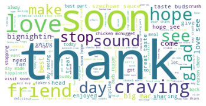

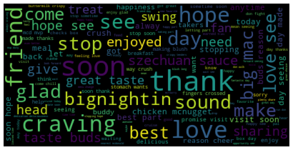

```python
# Example 3c: Elon Musk Speech 2017 with and without Stop Words
from os import path
from wordcloud import WordCloud, STOPWORDS
import matplotlib.pyplot as plt
%matplotlib inline


text = str(review)
text = text.replace("'", '')
text = text.replace(',', '')

# Take out some stopwords that are generic
stopwords = set(STOPWORDS)
stopwords.add("br")
stopwords.add("s")
stopwords.add("movie")
stopwords.add("film")
stopwords.add("films")
background_color="movies"



# Generate a word cloud image
wordcloud = WordCloud(background_color="white", max_words=2000).generate(text)

# Display the generated image:
# the matplotlib way:
plt.imshow(wordcloud)
plt.axis("off")

# take relative word frequencies into account, lower max_font_size
wordcloud = WordCloud(max_font_size=40, relative_scaling=.5, stopwords=stopwords).generate(text)
plt.figure(figsize=(10,10))
plt.imshow(wordcloud)
plt.axis("off")
```

# WordCloud for TacoBell

```python
df1=pd.read_csv("/Users/rajivpuli/Desktop/Tacobell.csv")
df1.head()
```

|  | author_id | Tweet | wordcount | avgwordlen | URL |
| --- | --- | --- | --- | --- | --- |
| 0 | TacoBellTeam | let talk https fusmrwstis | 50 | 70.389867 | True |
| 1 | TacoBellTeam | thanks for the heads wtf | 50 | 70.389867 | False |
| 2 | TacoBellTeam | let talk https fusmrwstis | 50 | 70.389867 | True |
| 3 | TacoBellTeam | let talk https fusmrwstis | 50 | 70.389867 | True |
| 4 | TacoBellTeam | let remake that | 33 | 70.389867 | False |

```python
df_t1= df1.drop(['author_id','wordcount','avgwordlen','URL'], axis=1)
df_t1.head()
```

|  | Tweet |
| --- | --- |
| 0 | let talk https fusmrwstis |
| 1 | thanks for the heads wtf |
| 2 | let talk https fusmrwstis |
| 3 | let talk https fusmrwstis |
| 4 | let remake that |

```python
df_t1.to_csv("/Users/rajivpuli/Desktop/HW 3/TacoBellCleaned", index=False)
```

```python
review = []
openfile = open('/Users/rajivpuli/Desktop/TacoBellCleaned.csv', 'r')
# openfile = open('data/sampledata_wordfrequency.csv', 'r', encoding = "ISO-8859-1")
r = csv.reader(openfile)
for i in r:
# get the first column only (ignoring the second column)
    review.append(i)
openfile.close()


len(review)
```

```
1596
```

```python
# Action 2 Required. What are the most popular words (50) - Use Lemmatizing.

# what if you have additional stopwords to be removed
tokens = str(review)
#lowercase
tokens = tokens.lower()
# Remove useless numbers and alphanumerical words
tokens = re.sub("[^a-zA-Z0-9]", " ", tokens)
#tokenization or word split
tokens = word_tokenize(tokens)
#get stemming words or lemmas
wordnet_lemmatizer = WordNetLemmatizer()                             #Using Lemmatizer method.
tokens = (wordnet_lemmatizer.lemmatize(word) for word in tokens)
#additional stopwrods
#more_stopwords = set(('cant', 'aint', 'today'))
#extra_stoplist = set(stopwords.words('english')) | more_stopwords
tokens = (word for word in tokens if word not in extra_stoplist)
# Filter non-alphanumeric characters from tokens
tokens = (word for word in tokens if word.isalpha())
#remove short words
tokens = (word for word in tokens if len(word) >= 3)

#fdist = nltk.FreqDist(tokens)
#fdist

#fdist.most_common(50)
```

```
(-0.5, 399.5, 199.5, -0.5)
```

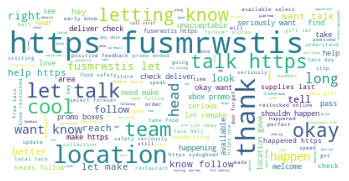

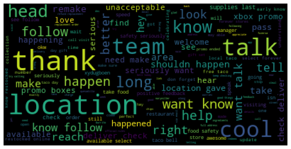

```python
# Example 3c: Elon Musk Speech 2017 with and without Stop Words
from os import path
from wordcloud import WordCloud, STOPWORDS
import matplotlib.pyplot as plt
%matplotlib inline


text = str(review)
text = text.replace("'", '')
text = text.replace(',', '')

# Take out some stopwords that are generic
stopwords = set(STOPWORDS)
stopwords.add("https")
stopwords.add("fusmrwstis")
stopwords.add("let")
stopwords.add("letting")
stopwords.add("okay")
background_color="movies"



# Generate a word cloud image
wordcloud = WordCloud(background_color="white", max_words=2000).generate(text)

# Display the generated image:
# the matplotlib way:
plt.imshow(wordcloud)
plt.axis("off")

# take relative word frequencies into account, lower max_font_size
wordcloud = WordCloud(max_font_size=40, relative_scaling=.5, stopwords=stopwords).generate(text)
plt.figure(figsize=(10,10))
plt.imshow(wordcloud)
plt.axis("off")
```

### Sentiment analysis

Show the results of sentiment analysis (Using **Pattern or Bing Liu**). I would be interested in how many positive / negative tweets are in the data. Create a column containing sentiment score. Do this for Taco Bell and McDonalds.

```python
# Example 1: Using sentiment:
# polarity is a value between -1.0 and +1.0 (-1 very negative and 1 very positive) and
# subjectivity between 0.0 and 1.0 (0 is very objective, 1 is very subjective).

from pattern.en import sentiment
import csv
import pandas as pd

import re

import nltk
from nltk.corpus import stopwords
```

```python
# Example 4a: Grabbing Tweets from CSV File
reviews = []
openfile = open('/Users/rajivpuli/Desktop/McDonaldsCleaned', 'r')
r = csv.reader(openfile)
for i in r:
    reviews.append(i)
openfile.close()
reviews[:5]
```

```
[['["[\'Tweet\']", \'0.0\', \'0.0\']', '0.0', '0.0'],
 ['["[\'getting all sorts saucy over here this halloween trickortweet https anlyzyvl\']", \'0.0\', \'0.0\']',
  '0.0',
  '0.0'],
 ['["[\'what this halloween trick treat let know below trickortweet https xwjazp\']", \'0.0\', \'0.0\']',
  '0.0',
  '0.0'],
 ['["[\'our heart beating faster over here and not from all the scares trickortweet https wte flifj\']", \'0.0\', \'0.0\']',
  '0.0',
  '0.0'],
 ['["[\'chocolate chip cookies mcflurry everything you ever been missing trickortweet https yfwchlnkt\']", \'-0.2\', \'0.05\']',
  '-0.2',
  '0.05']]
```

```python
# Example 4b: How many tweets?
len(reviews)
```

```
3972
```

```python
#Example 4d: Cleaning Text
# remove extra brackets
reviews = [x for y in reviews for x in y]
# Remove useless numbers and alphanumerical words
documents = [re.sub("[^a-zA-Z]+", " ", document) for document in reviews]
# tokenize
texts = [[word for word in document.lower().split() ] for document in documents]
# remove common words
stoplist = stopwords.words('english')
texts = [[word for word in text if word not in stoplist] for text in texts]
#remove short words
texts = [[ word for word in tokens if len(word) >= 3 ] for tokens in texts]

for row in texts[:5]:
    data = str(row)
    data = data.replace("'", '')
    data = data.replace(',', '')
    score = sentiment(data)
    print(round(score[0],3), round(score[1],3))
```

```
0.0 0.0
0.0 0.0
0.0 0.0
0.0 0.0
0.0 0.0
```

```python
# Only saving scores not Tweets with Scores

reviews = []
openfile = open('/Users/rajivpuli/Desktop/McDonaldsCleaned', 'r')
r = csv.reader(openfile)
for i in r:
    reviews.append(i)
openfile.close()

score=[]
for row in reviews:
    score.append(sentiment(str(row)))
```

```python
for i in reviews[:5]:
    print(i)
```

```
['["[\'Tweet\']", \'0.0\', \'0.0\']', '0.0', '0.0']
['["[\'getting all sorts saucy over here this halloween trickortweet https anlyzyvl\']", \'0.0\', \'0.0\']', '0.0', '0.0']
['["[\'what this halloween trick treat let know below trickortweet https xwjazp\']", \'0.0\', \'0.0\']', '0.0', '0.0']
['["[\'our heart beating faster over here and not from all the scares trickortweet https wte flifj\']", \'0.0\', \'0.0\']', '0.0', '0.0']
['["[\'chocolate chip cookies mcflurry everything you ever been missing trickortweet https yfwchlnkt\']", \'-0.2\', \'0.05\']', '-0.2', '0.05']
```

```python
# Review Data
for item in score[:5]:
    print(item[0], ",", item[1])
```

```
0.0 , 0.0
0.0 , 0.0
0.0 , 0.0
0.0 , 0.0
-0.2 , 0.05
```

```python
positive_review = []
negative_review = []
neutral_review = []

for row in reviews:
    tweet = str(row)
    score = sentiment(tweet)
    if score[0] > 0:
        positive_review.append(tweet)
    elif score[0] == 0:
        neutral_review.append(tweet)
    else:
        negative_review.append(tweet)
```

```python
for row in reviews[:5]:
    print(row)
```

```
['["[\'Tweet\']", \'0.0\', \'0.0\']', '0.0', '0.0']
['["[\'getting all sorts saucy over here this halloween trickortweet https anlyzyvl\']", \'0.0\', \'0.0\']', '0.0', '0.0']
['["[\'what this halloween trick treat let know below trickortweet https xwjazp\']", \'0.0\', \'0.0\']', '0.0', '0.0']
['["[\'our heart beating faster over here and not from all the scares trickortweet https wte flifj\']", \'0.0\', \'0.0\']', '0.0', '0.0']
['["[\'chocolate chip cookies mcflurry everything you ever been missing trickortweet https yfwchlnkt\']", \'-0.2\', \'0.05\']', '-0.2', '0.05']
```

```python
print(len(positive_review))
print(len(negative_review))
print(len(neutral_review))
```

```
2212
199
1561
```

```python
# Example 7a: remove all urls
documents = [re.sub(r"http\S+", '', document) for document in positive_review]
# Remove useless numbers and alphanumerical words
documents = [re.sub("[^a-zA-Z]+", " ", document) for document in documents]
# tokenize
texts = [document.lower().split() for document in documents]
# remove common words
stoplist = stopwords.words('english')
texts = [[word for word in text if word not in stoplist] for text in texts]
#remove short words
texts = [[ word for word in tokens if len(word) >= 3 ] for tokens in texts]
```

```python
# Example 7b: remove extra brackets)
cleaned_positive_review_tokens = [x for y in texts for x in y]
cleaned_positive_review_tokens[:10]
```

```
['coke',
 'looks',
 'good',
 'almost',
 'taste',
 'almost',
 'trickortweet',
 'xqznqanypf',
 'halloween',
 'perfect']
```

# Positive Reviews

```python
# Example 7c: word frequency
from collections import Counter

positive_review_wordcounts= Counter(cleaned_positive_review_tokens)
positive_review_wordcounts.most_common(10)
```

```
[('thanks', 480),
 ('love', 417),
 ('soon', 369),
 ('see', 366),
 ('day', 332),
 ('hope', 276),
 ('best', 224),
 ('like', 224),
 ('glad', 210),
 ('great', 197)]
```

## Negative Review

```python
# Example 7a: remove all urls
documents = [re.sub(r"http\S+", '', document) for document in negative_review]
# Remove useless numbers and alphanumerical words
documents = [re.sub("[^a-zA-Z]+", " ", document) for document in documents]
# tokenize
texts = [document.lower().split() for document in documents]
# remove common words
stoplist = stopwords.words('english')
texts = [[word for word in text if word not in stoplist] for text in texts]
#remove short words
texts = [[ word for word in tokens if len(word) >= 3 ] for tokens in texts]
```

```python
# Example 7b: remove extra brackets)
cleaned_negative_review_tokens = [x for y in texts for x in y]
cleaned_negative_review_tokens[:10]
```

```
['chocolate',
 'chip',
 'cookies',
 'mcflurry',
 'everything',
 'ever',
 'missing',
 'trickortweet',
 'yfwchlnkt',
 'chocolate']
```

```python
# Example 7c: word frequency
from collections import Counter

negative_review_wordcounts= Counter(cleaned_negative_review_tokens)
negative_review_wordcounts.most_common(10)
```

```
[('soon', 64),
 ('chicken', 51),
 ('hope', 49),
 ('mean', 44),
 ('seeing', 40),
 ('mcnuggets', 39),
 ('thanks', 38),
 ('unfortunately', 29),
 ('get', 25),
 ('sorry', 25)]
```

# TacoBell

## Positive Reviews

```python
# Example 4a: Grabbing Tweets from CSV File
reviews = []
openfile = open('/Users/rajivpuli/Desktop/TacoBellCleaned.csv', 'r')
r = csv.reader(openfile)
for i in r:
    reviews.append(i)
openfile.close()
reviews[:5]
```

```
[['Tweet'],
 ['let talk https fusmrwstis'],
 ['thanks for the heads wtf'],
 ['let talk https fusmrwstis'],
 ['let talk https fusmrwstis']]
```

```python
# Example 4b: How many tweets?
len(reviews)
```

```
1596
```

```python
#Example 4d: Cleaning Text
# remove extra brackets
reviews = [x for y in reviews for x in y]
# Remove useless numbers and alphanumerical words
documents = [re.sub("[^a-zA-Z]+", " ", document) for document in reviews]
# tokenize
texts = [[word for word in document.lower().split() ] for document in documents]
# remove common words
stoplist = stopwords.words('english')
texts = [[word for word in text if word not in stoplist] for text in texts]
#remove short words
texts = [[ word for word in tokens if len(word) >= 3 ] for tokens in texts]

for row in texts[:5]:
    data = str(row)
    data = data.replace("'", '')
    data = data.replace(',', '')
    score = sentiment(data)
    print(round(score[0],3), round(score[1],3))
```

```
0.0 0.0
0.0 0.0
-0.15 0.6
0.0 0.0
0.0 0.0
```

```python
# Only saving scores not Tweets with Scores

reviews = []
openfile = open('/Users/rajivpuli/Desktop/TacoBellCleaned.csv', 'r')
r = csv.reader(openfile)
for i in r:
    reviews.append(i)
openfile.close()

score=[]
for row in reviews:
    score.append(sentiment(str(row)))
```

```python
for i in reviews[:5]:
    print(i)
```

```
['Tweet']
['let talk https fusmrwstis']
['thanks for the heads wtf']
['let talk https fusmrwstis']
['let talk https fusmrwstis']
```

```python
# Review Data
for item in score[:5]:
    print(item[0], ",", item[1])
```

```
0.0 , 0.0
0.0 , 0.0
-0.15 , 0.6
0.0 , 0.0
0.0 , 0.0
```

```python
positive_review = []
negative_review = []
neutral_review = []

for row in reviews:
    tweet = str(row)
    score = sentiment(tweet)
    if score[0] > 0:
        positive_review.append(tweet)
    elif score[0] == 0:
        neutral_review.append(tweet)
    else:
        negative_review.append(tweet)
```

```python
for row in reviews[:5]:
    print(row)
```

```
['Tweet']
['let talk https fusmrwstis']
['thanks for the heads wtf']
['let talk https fusmrwstis']
['let talk https fusmrwstis']
```

```python
print(len(positive_review))
print(len(negative_review))
print(len(neutral_review))
```

```
517
455
624
```

```python
# Example 7a: remove all urls
documents = [re.sub(r"http\S+", '', document) for document in positive_review]
# Remove useless numbers and alphanumerical words
documents = [re.sub("[^a-zA-Z]+", " ", document) for document in documents]
# tokenize
texts = [document.lower().split() for document in documents]
# remove common words
stoplist = stopwords.words('english')
texts = [[word for word in text if word not in stoplist] for text in texts]
#remove short words
texts = [[ word for word in tokens if len(word) >= 3 ] for tokens in texts]
```

```python
# Example 7b: remove extra brackets)
cleaned_positive_review_tokens = [x for y in texts for x in y]
cleaned_positive_review_tokens[:10]
```

```
['okay',
 'fusmrwstis',
 'better',
 'better',
 'thanks',
 'letting',
 'know',
 'thanks',
 'emma',
 'thanks']
```

```python
# Example 7c: word frequency
from collections import Counter

positive_review_wordcounts= Counter(cleaned_positive_review_tokens)
positive_review_wordcounts.most_common(10)
```

```
[('thanks', 272),
 ('know', 181),
 ('team', 124),
 ('fusmrwstis', 118),
 ('letting', 111),
 ('heads', 84),
 ('follow', 71),
 ('want', 61),
 ('better', 41),
 ('okay', 29)]
```

## Negative Reviews

```python
# Example 7a: remove all urls
documents = [re.sub(r"http\S+", '', document) for document in negative_review]
# Remove useless numbers and alphanumerical words
documents = [re.sub("[^a-zA-Z]+", " ", document) for document in documents]
# tokenize
texts = [document.lower().split() for document in documents]
# remove common words
stoplist = stopwords.words('english')
texts = [[word for word in text if word not in stoplist] for text in texts]
#remove short words
texts = [[ word for word in tokens if len(word) >= 3 ] for tokens in texts]
```

```python
# Example 7b: remove extra brackets)
cleaned_negative_review_tokens = [x for y in texts for x in y]
cleaned_negative_review_tokens[:10]
```

```
['thanks',
 'heads',
 'wtf',
 'serious',
 'long',
 'happen',
 'long',
 'happen',
 'okay',
 'let']
```

```python
# Example 7c: word frequency
from collections import Counter

negative_review_wordcounts= Counter(cleaned_negative_review_tokens)
negative_review_wordcounts.most_common(10)
```

```
[('location', 165),
 ('cool', 149),
 ('okay', 141),
 ('fusmrwstis', 126),
 ('talk', 71),
 ('long', 62),
 ('get', 56),
 ('let', 52),
 ('right', 37),
 ('take', 34)]
```

What is the overall sentiment in the data for each Taco Bell and McDonalds? Average sentiment score

# Average Sentiment Score McDonalds

```python
# Example 4a: Grabbing Tweets from CSV File
reviews = []
openfile = open('/Users/rajivpuli/Desktop/McDonaldsCleaned copy.csv', 'r')
r = csv.reader(openfile)
for i in r:
    reviews.append(i)
openfile.close()
```

```python
# Example 4b: How many tweets?
len(reviews)
```

```
3972
```

```python
# Example 4c: without text preprocessing ... this is good enough?
for row in reviews[:5]:
    tweet = str(row)
    score = sentiment(tweet)
    print(round(score[0],3), round(score[1],3))
```

```
0.0 0.0
0.0 0.0
0.0 0.0
0.0 0.0
-0.2 0.05
```

```python
#Example 4d: Cleaning Text
# remove extra brackets
reviews = [x for y in reviews for x in y]
# Remove useless numbers and alphanumerical words
documents = [re.sub("[^a-zA-Z]+", " ", document) for document in reviews]
# tokenize
texts = [[word for word in document.lower().split() ] for document in documents]
# remove common words
stoplist = stopwords.words('english')
texts = [[word for word in text if word not in stoplist] for text in texts]
#remove short words
texts = [[ word for word in tokens if len(word) >= 3 ] for tokens in texts]

for row in texts[:5]:
    data = str(row)
    data = data.replace("'", '')
    data = data.replace(',', '')
    score = sentiment(data)
    print(round(score[0],3), round(score[1],3))
```

```
0.0 0.0
0.0 0.0
0.0 0.0
0.0 0.0
-0.2 0.05
```

```python
# Only saving scores not Tweets with Scores

reviews = []
openfile = open('/Users/rajivpuli/Desktop/McDonaldsCleaned', 'r')
r = csv.reader(openfile)
for i in r:
    reviews.append(i)
openfile.close()

score=[]
for row in reviews:
    score.append(sentiment(str(row)))

writefile = open('/Users/rajivpuli/Desktop/output_sentiscore_altmethod.csv', 'w')
output=list(zip(score))
w = csv.writer(writefile)
w.writerows(output)

writefile.close()
```

```python
sm=pd.read_csv("/Users/rajivpuli/Desktop/output_sentiscore_altmethod.csv")
sm.head(5)
```

|  | Sentiment Score |
| --- | --- |
| 0 | (0.0, 0.0) |
| 1 | (0.0, 0.0) |
| 2 | (0.0, 0.0) |
| 3 | (-0.2, 0.05) |
| 4 | (0.0, 0.0) |

```python
mc=pd.read_csv("/Users/rajivpuli/Desktop/McDonaldsCleaned copy.csv")
mc.head(5)
```

|  | Tweet |
| --- | --- |
| 0 | getting all sorts saucy over here this hallowe... |
| 1 | what this halloween trick treat let know below... |
| 2 | our heart beating faster over here and not fro... |
| 3 | chocolate chip cookies mcflurry everything you... |
| 4 | don forget this sunday bring your grandma mcdo... |

```python
mc['Sentiment_Score'] = sm['Sentiment Score']
mc.head(5)
```

|  | Tweet | Sentiment_Score |
| --- | --- | --- |
| 0 | getting all sorts saucy over here this hallowe... | (0.0, 0.0) |
| 1 | what this halloween trick treat let know below... | (0.0, 0.0) |
| 2 | our heart beating faster over here and not fro... | (0.0, 0.0) |
| 3 | chocolate chip cookies mcflurry everything you... | (-0.2, 0.05) |
| 4 | don forget this sunday bring your grandma mcdo... | (0.0, 0.0) |

```python
mc['OverallSentimentscore'] = mc['Sentiment_Score'].sum()
mc.head(5)
```

|  | Tweet | Sentiment_Score | OverallSentimentscore |
| --- | --- | --- | --- |
| 0 | getting all sorts saucy over here this hallowe... | (0.0, 0.0) | (0.0, 0.0)(0.0, 0.0)(0.0, 0.0)(-0.2, 0.05)(0.0... |
| 1 | what this halloween trick treat let know below... | (0.0, 0.0) | (0.0, 0.0)(0.0, 0.0)(0.0, 0.0)(-0.2, 0.05)(0.0... |
| 2 | our heart beating faster over here and not fro... | (0.0, 0.0) | (0.0, 0.0)(0.0, 0.0)(0.0, 0.0)(-0.2, 0.05)(0.0... |
| 3 | chocolate chip cookies mcflurry everything you... | (-0.2, 0.05) | (0.0, 0.0)(0.0, 0.0)(0.0, 0.0)(-0.2, 0.05)(0.0... |
| 4 | don forget this sunday bring your grandma mcdo... | (0.0, 0.0) | (0.0, 0.0)(0.0, 0.0)(0.0, 0.0)(-0.2, 0.05)(0.0... |

# TacoBell Sentiment Score

```python
# Example 4a: Grabbing Tweets from CSV File
reviews = []
openfile = open('/Users/rajivpuli/Desktop/TacoBellCleaned.csv', 'r')
r = csv.reader(openfile)
for i in r:
    reviews.append(i)
openfile.close()
```

```python
# Example 4c: without text preprocessing ... this is good enough?
for row in reviews[:5]:
    tweet = str(row)
    score = sentiment(tweet)
    print(round(score[0],3), round(score[1],3))
```

```
0.0 0.0
0.0 0.0
-0.15 0.6
0.0 0.0
0.0 0.0
```

```python
#Example 4d: Cleaning Text
# remove extra brackets
reviews = [x for y in reviews for x in y]
# Remove useless numbers and alphanumerical words
documents = [re.sub("[^a-zA-Z]+", " ", document) for document in reviews]
# tokenize
texts = [[word for word in document.lower().split() ] for document in documents]
# remove common words
stoplist = stopwords.words('english')
texts = [[word for word in text if word not in stoplist] for text in texts]
#remove short words
texts = [[ word for word in tokens if len(word) >= 3 ] for tokens in texts]

for row in texts[:5]:
    data = str(row)
    data = data.replace("'", '')
    data = data.replace(',', '')
    score = sentiment(data)
    print(round(score[0],3), round(score[1],3))
```

```
0.0 0.0
0.0 0.0
-0.15 0.6
0.0 0.0
0.0 0.0
```

```python
# Only saving scores not Tweets with Scores

reviews = []
openfile = open('/Users/rajivpuli/Desktop/TacoBellCleaned.csv', 'r')
r = csv.reader(openfile)
for i in r:
    reviews.append(i)
openfile.close()

score=[]
for row in reviews:
    score.append(sentiment(str(row)))

writefile = open('/Users/rajivpuli/Desktop/output_sentiscore.csv', 'w')
output=list(zip(score))
w = csv.writer(writefile)
w.writerows(output)

writefile.close()
```

```python
sc=pd.read_csv("/Users/rajivpuli/Desktop/output_sentiscore.csv")
sc.head(5)
```

|  | Sentiment Score |
| --- | --- |
| 0 | (0.0, 0.0) |
| 1 | (-0.15, 0.6) |
| 2 | (0.0, 0.0) |
| 3 | (0.0, 0.0) |
| 4 | (0.0, 0.0) |

```python
tb1=pd.read_csv("/Users/rajivpuli/Desktop/TacoBellCleaned.csv")
tb1.head(5)
```

|  | Tweet |
| --- | --- |
| 0 | let talk https fusmrwstis |
| 1 | thanks for the heads wtf |
| 2 | let talk https fusmrwstis |
| 3 | let talk https fusmrwstis |
| 4 | let remake that |

```python
tb1['Sentiment_Score'] = sc['Sentiment Score']
tb1.head(5)
```

|  | Tweet | Sentiment_Score |
| --- | --- | --- |
| 0 | let talk https fusmrwstis | (0.0, 0.0) |
| 1 | thanks for the heads wtf | (-0.15, 0.6) |
| 2 | let talk https fusmrwstis | (0.0, 0.0) |
| 3 | let talk https fusmrwstis | (0.0, 0.0) |
| 4 | let remake that | (0.0, 0.0) |

```python
tb1['OverallSentimentscore'] = tb1['Sentiment_Score'].sum()
tb1.head(5)
```

|  | Tweet | Sentiment_Score | OverallSentimentscore |
| --- | --- | --- | --- |
| 0 | let talk https fusmrwstis | (0.0, 0.0) | (0.0, 0.0)(-0.15, 0.6)(0.0, 0.0)(0.0, 0.0)(0.0... |
| 1 | thanks for the heads wtf | (-0.15, 0.6) | (0.0, 0.0)(-0.15, 0.6)(0.0, 0.0)(0.0, 0.0)(0.0... |
| 2 | let talk https fusmrwstis | (0.0, 0.0) | (0.0, 0.0)(-0.15, 0.6)(0.0, 0.0)(0.0, 0.0)(0.0... |
| 3 | let talk https fusmrwstis | (0.0, 0.0) | (0.0, 0.0)(-0.15, 0.6)(0.0, 0.0)(0.0, 0.0)(0.0... |
| 4 | let remake that | (0.0, 0.0) | (0.0, 0.0)(-0.15, 0.6)(0.0, 0.0)(0.0, 0.0)(0.0... |

Run the Readability Indexes on the Data. How do the scores compare between McDonalds and Taco Bell?

# McDonalds

```python
# Example 1: Import NLTK and TextStat for Readability
# May needs to pip install textstat
# textstat is a Python package to calculate statistics from text
# Determines readability, complexity and grade level of a particular corpus.
import nltk
import textstat
import pandas as pd
from nltk.tokenize import sent_tokenize, word_tokenize
import re
import pandas as pd
from nltk.corpus import stopwords
import csv
```

```python
# Example 13: Assess Readability of a Customer Service Tweets
# Example 13a: Get CSV File Contents (you many need to change the file path)
# Setup and Clear all lists in case
tweets = []
fleschre = []
smog = []
fleschkg = []
colemanliau = []
ari = []
dalchall = []
dw = []
linsearwrite = []
gunningfog = []
textstandard = []
tweets.clear()
textstandard.clear()
fleschre.clear()
smog.clear()
fleschkg.clear()
colemanliau.clear()
ari.clear()
dalchall.clear()
dw.clear()
linsearwrite.clear()
gunningfog.clear()

#openfile = open('data/sampledata_wordfrequency.csv', 'r', encoding = "ISO-8859-1")

openfile = open("/Users/rajivpuli/Desktop/McDonaldsCleaned copy.csv", "r", encoding = "ISO-8859-1")
r = csv.reader(openfile)

# Example 13b: Set idex value to -1
j=-1



# Example 13c: Put all tweets into a list
for i in r:
    j=j+1
    tweets.append(i)

    # Example 13d: Find out if Tweet can be used with Smog Index (used tokenization this time)
    number_sentences = len(sent_tokenize(str(tweets[j])))

    if number_sentences < 3:
        # Put N/A into SMOG List for Tweet
        smog.append('N/A')
    else:
        # Put score into smog list for Tweet
        smog.append(textstat.smog_index(str(tweets[j])))

    # Example 13e: Put each Score into a list that corresponds to Tweets
    fleschre.append(textstat.flesch_reading_ease(str(tweets[j])))
    fleschkg.append(textstat.flesch_kincaid_grade(str(tweets[j])))
    colemanliau.append(textstat.coleman_liau_index(str(tweets[j])))
    ari.append(textstat.automated_readability_index(str(tweets[j])))
    dalchall.append(textstat.dale_chall_readability_score(str(tweets[j])))
    dw.append(textstat.difficult_words(str(tweets[j])))
    linsearwrite.append(textstat.linsear_write_formula(str(tweets[j])))
    gunningfog.append(textstat.gunning_fog(str(tweets[j])))

    # Example 13e: Check for invalid Composite scores
    if textstat.text_standard(str(tweets[j])) != '-1th and 0th grade':
        textstandard.append(textstat.text_standard(str(tweets[j])))
    else:
        textstandard.append('N/A')

# Example 13f: All done so close csv file
openfile.close()

#print(tweets)
```

```python
# Example 14: Put Scores into a DataFrame

df= pd.DataFrame()
df['tweets'] = tweets
df['fleschre'] = fleschre
df['smog'] = smog
df['fleschkg'] = fleschkg
df['colemanliau'] = colemanliau
df['ari'] = ari
df['dalchall'] = dalchall
df['dw'] = dw
df['linsearwrite'] = linsearwrite
df['gunningfog'] = gunningfog
df['textstandard'] = textstandard

df.head(10)
```

|  | tweets | fleschre | smog | fleschkg | colemanliau | ari | dalchall | dw | linsearwrite | gunningfog | textstandard |
| --- | --- | --- | --- | --- | --- | --- | --- | --- | --- | --- | --- |
| 0 | [Tweet] | 121.22 | N/A | -3.5 | -16.41 | 21.5 | 19.48 | 0 | -0.5 | 0.40 | N/A |
| 1 | [getting all sorts saucy over here this hallow... | 68.77 | N/A | 6.4 | 16.34 | 14.0 | 14.23 | 4 | 5.5 | 8.04 | 5th and 6th grade |
| 2 | [what this halloween trick treat let know belo... | 68.77 | N/A | 6.4 | 14.25 | 12.3 | 11.36 | 3 | 5.5 | 8.04 | 5th and 6th grade |
| 3 | [our heart beating faster over here and not fr... | 89.08 | N/A | 4.8 | 9.97 | 10.1 | 11.34 | 1 | 8.0 | 8.90 | 9th and 10th grade |
| 4 | [chocolate chip cookies mcflurry everything yo... | 42.38 | N/A | 10.3 | 21.45 | 18.3 | 12.13 | 4 | 7.0 | 8.13 | 10th and 11th grade |
| 5 | [don forget this sunday bring your grandma mcd... | 76.22 | N/A | 5.6 | 8.92 | 8.1 | 8.18 | 1 | 6.0 | 8.13 | 8th and 9th grade |
| 6 | [this coke looks good you can almost taste alm... | 76.22 | N/A | 5.6 | 14.20 | 12.5 | 12.13 | 2 | 6.0 | 8.13 | 5th and 6th grade |
| 7 | [bird plane balloon french fry box trickortwee... | 87.72 | N/A | 3.3 | 13.19 | 11.3 | 11.10 | 1 | 4.5 | 8.04 | N/A |
| 8 | [our heart beating faster over here and not fr... | 81.63 | N/A | 5.6 | 11.13 | 10.9 | 10.70 | 2 | 7.5 | 8.67 | 10th and 11th grade |
| 9 | [our heart beating faster over here and not fr... | 91.11 | N/A | 4.0 | 10.32 | 9.8 | 9.97 | 1 | 7.0 | 8.46 | 9th and 10th grade |

# TacoBell

```python
# Example 13: Assess Readability of a Customer Service Tweets
# Example 13a: Get CSV File Contents (you many need to change the file path)
# Setup and Clear all lists in case
tweets = []
fleschre = []
smog = []
fleschkg = []
colemanliau = []
ari = []
dalchall = []
dw = []
linsearwrite = []
gunningfog = []
textstandard = []
tweets.clear()
textstandard.clear()
fleschre.clear()
smog.clear()
fleschkg.clear()
colemanliau.clear()
ari.clear()
dalchall.clear()
dw.clear()
linsearwrite.clear()
gunningfog.clear()

#openfile = open('data/sampledata_wordfrequency.csv', 'r', encoding = "ISO-8859-1")

openfile = open("/Users/rajivpuli/Desktop/TacoBellCleaned.csv", "r", encoding = "ISO-8859-1")
r = csv.reader(openfile)

# Example 13b: Set idex value to -1
j=-1



# Example 13c: Put all tweets into a list
for i in r:
    j=j+1
    tweets.append(i)

    # Example 13d: Find out if Tweet can be used with Smog Index (used tokenization this time)
    number_sentences = len(sent_tokenize(str(tweets[j])))

    if number_sentences < 3:
        # Put N/A into SMOG List for Tweet
        smog.append('N/A')
    else:
        # Put score into smog list for Tweet
        smog.append(textstat.smog_index(str(tweets[j])))

    # Example 13e: Put each Score into a list that corresponds to Tweets
    fleschre.append(textstat.flesch_reading_ease(str(tweets[j])))
    fleschkg.append(textstat.flesch_kincaid_grade(str(tweets[j])))
    colemanliau.append(textstat.coleman_liau_index(str(tweets[j])))
    ari.append(textstat.automated_readability_index(str(tweets[j])))
    dalchall.append(textstat.dale_chall_readability_score(str(tweets[j])))
    dw.append(textstat.difficult_words(str(tweets[j])))
    linsearwrite.append(textstat.linsear_write_formula(str(tweets[j])))
    gunningfog.append(textstat.gunning_fog(str(tweets[j])))

    # Example 13e: Check for invalid Composite scores
    if textstat.text_standard(str(tweets[j])) != '-1th and 0th grade':
        textstandard.append(textstat.text_standard(str(tweets[j])))
    else:
        textstandard.append('N/A')

# Example 13f: All done so close csv file
openfile.close()

#print(tweets)
```

```python
# Example 14: Put Scores into a DataFrame

df= pd.DataFrame()
df['tweets'] = tweets
df['fleschre'] = fleschre
df['smog'] = smog
df['fleschkg'] = fleschkg
df['colemanliau'] = colemanliau
df['ari'] = ari
df['dalchall'] = dalchall
df['dw'] = dw
df['linsearwrite'] = linsearwrite
df['gunningfog'] = gunningfog
df['textstandard'] = textstandard

df.head(10)
```

|  | tweets | fleschre | smog | fleschkg | colemanliau | ari | dalchall | dw | linsearwrite | gunningfog | textstandard |
| --- | --- | --- | --- | --- | --- | --- | --- | --- | --- | --- | --- |
| 0 | [Tweet] | 121.22 | N/A | -3.5 | -16.41 | 21.5 | 19.48 | 0 | -0.5 | 0.4 | N/A |
| 1 | [let talk https fusmrwstis] | 50.50 | N/A | 7.2 | 8.70 | 11.2 | 15.68 | 1 | 2.0 | 11.6 | 11th and 12th grade |
| 2 | [thanks for the heads wtf] | 117.16 | N/A | -1.9 | 1.48 | 3.7 | 13.36 | 0 | 1.5 | 2.0 | 1st and 2nd grade |
| 3 | [let talk https fusmrwstis] | 50.50 | N/A | 7.2 | 8.70 | 11.2 | 15.68 | 1 | 2.0 | 11.6 | 11th and 12th grade |
| 4 | [let talk https fusmrwstis] | 50.50 | N/A | 7.2 | 8.70 | 11.2 | 15.68 | 1 | 2.0 | 11.6 | 11th and 12th grade |
| 5 | [let remake that] | 93.81 | N/A | 0.9 | -0.46 | 6.8 | 19.58 | 1 | 0.5 | 1.2 | 0th and 1st grade |
| 6 | [let talk https fusmrwstis] | 50.50 | N/A | 7.2 | 8.70 | 11.2 | 15.68 | 1 | 2.0 | 11.6 | 11th and 12th grade |
| 7 | [let talk https fusmrwstis] | 50.50 | N/A | 7.2 | 8.70 | 11.2 | 15.68 | 1 | 2.0 | 11.6 | 11th and 12th grade |
| 8 | [this serious] | 35.61 | N/A | 8.8 | 1.30 | 14.9 | 19.53 | 1 | 1.0 | 20.8 | 0th and 1st grade |
| 9 | [let make https fusmrwstis] | 50.50 | N/A | 7.2 | 8.70 | 11.2 | 15.68 | 1 | 2.0 | 11.6 | 11th and 12th grade |

```
Extra Credit: Show the results of sentiment analysis a second time (Using **vaderSentiment**) without cleaning the data first. Briefly comment on difference between your first analysis and the the second one. Remember, we often don't clean Vader Sentiment Analysis data to retain context!
```

# Vader Sentiment Analysis

```python
import csv
import re
import pandas as pd

import nltk
from nltk.corpus import stopwords

# sentiment analysis  (if not found: pip install vaderSentiment at command prompt)
from nltk.sentiment.vader import SentimentIntensityAnalyzer

nltk.download('vader_lexicon')
```

```
True
```

```python
# Example 2a: Number of Rows
openfile = open("/Users/rajivpuli/Desktop/TacoBellvsMcDonalds.csv", "r", encoding='utf-8')
r = csv.reader(openfile)
reviews = []
for i in r:
    reviews.append(i)
openfile.close()
len(reviews)
```

```
5567
```

```python
# Set up lists

positive_review = []
negative_review = []
neutral_review = []


analyzer = SentimentIntensityAnalyzer()

# Remove brackets - added....
reviews = [x for y in reviews for x in y]

# Remove the unwanted characters - Okay not to use this with VADER
#documents = [re.sub("[^a-zA-Z]+", " ", document) for document in reviews]

# Make lower - Okay not to use this with VADER
#texts = [[word for word in document.lower().split() ]for document in documents]


# Might be good not to use Data Frames right now.
#df = pd.DataFrame(reviews)
#df.columns = ['review']
#df.head(5)

#for sentence in documents:
#    vs=analyzer.polarity_scores(sentence)
#    df['compound'] = vs["compound"]
#df.head(5)

# Do what you did but this time put into array rather than dataframe
for sentence in reviews:
    vs = analyzer.polarity_scores(sentence)
    if (vs["compound"] > 0):
        positive_review.append(sentence)
    elif (vs["compound"] == 0):
        neutral_review.append(sentence)
    else:
        negative_review.append(sentence)
print(len(positive_review), 'positive reviews')
print(len(negative_review), 'negative reviews')
print(len(neutral_review), 'neutral reviews')
```

```
3726 positive reviews
957 negative reviews
6451 neutral reviews
```

```python
from collections import Counter

positive_review_wordcounts= Counter(positive_review)
positive_review_wordcounts.most_common(1)
```

```
[('@159772 Thanks for stopping by! We hope you enjoyed your meal!', 2)]
```

```
(-0.5, 399.5, 199.5, -0.5)
```

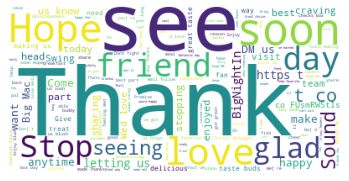

```python
# Now, do the word cloud for positive words!

from os import path
from wordcloud import WordCloud, STOPWORDS
import matplotlib.pyplot as plt
%matplotlib inline

text = str(positive_review)
text = text.replace("'", '')
text = text.replace(',', '')


# Take out some stopwords that are generic
stopwords = set(STOPWORDS)
stopwords.add("br")
stopwords.add("s")
stopwords.add("movie")
stopwords.add("film")
stopwords.add("films")
background_color="movies"

# Generate a word cloud image
#wc = WordCloud(background_color="white", max_words=2000).generate(text)
wc = WordCloud(background_color="white", relative_scaling=.5, max_words=2000, stopwords=stopwords).generate(text)
#wc.generate(text)

# Display the generated image:
# the matplotlib way:
plt.imshow(wc)
plt.axis("off")
```

```python
from collections import Counter

negative_review_wordcounts= Counter(negative_review)
negative_review_wordcounts.most_common(1)
```

```
[("@127797 Thanks for the heads up. We're on it. WTF!", 1)]
```

```
(-0.5, 399.5, 199.5, -0.5)
```

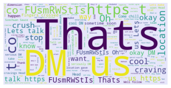

```python
from os import path
from wordcloud import WordCloud, STOPWORDS
import matplotlib.pyplot as plt
%matplotlib inline

text = str(negative_review)
text = text.replace("'", '')
text = text.replace(',', '')

# Take out some stopwords that are generic
stopwords = set(STOPWORDS)
stopwords.add("https")
stopwords.add("DM")
stopwords.add("US")
stopwords.add("t")
stopwords.add("CO")
background_color="movies"

# Generate a word cloud image
wc = WordCloud(background_color="lavender", max_words=2000).generate(text)
wc.generate(text)

# Display the generated image:
# the matplotlib way:
plt.imshow(wc)
plt.axis("off")
```